# Hw2

Eduardo Armenta

2022-10-05

# HW 2

## Problem 1

Consider the random variable defined by counting the number of failures until the first success, for inde- pendent trials with success probability p. Given p between 0 and 1, the **R** commands **myattempts(p)** and **rgeom(1,p)** both simulate this random variable. Find a way of demonstrating that the two commands indeed give the same results, for five different values of p. You may find the table() function useful.

Choose five p’s of your choice, e.g. p ∈ {.1, .3, .5, .7, .9}. Run myattempts and rgeom each 10000 times.

**a**. For the first p, store the fraction of outcomes in the simulation in the columns of a suitable data frame and compare (Hint: use 3 columns to compare rgeom(), myattempts() and dgeom() ) (10 points)

```r
# libraries
library(tidyverse)
# copying mytoss function
mytoss = function(p){
  u <- runif(1)
  x <- as.numeric(u < p)
  return(x)
}
myattempts = function(p){ counter <- 0
while (mytoss(p) == 0){ counter <- counter + 1 }
return(counter) }

# 1.1 how are we supposed to use rgeom() here?
sims <- 10000
p = .75
dfd1 <- data.frame(table(rgeom(sims,p)))[1:5,]
dfd2 <- data.frame(table(replicate(sims,myattempts(p))))[1:5,]
df <- data.frame(dfd1,dfd2)
df <- subset(df, select = -c(Var1.1))
names(df)[1] <- 'Unit'
names(df)[2] <- 'rgeom'
names(df)[3] <- 'myattempts'
df$rgeomFraction <- df$rgeom/10000
df$myattemptsFraction <- df$myattempts/10000
vector <- c(0,1,2,3,4)
df$dgeom <- dgeom(vector,.75)
df
```

```
##   Unit rgeom myattempts rgeomFraction myattemptsFraction       dgeom
## 1    0  7517       7441        0.7517             0.7441 0.750000000
## 2    1  1845       1877        0.1845             0.1877 0.187500000
## 3    2   481        518        0.0481             0.0518 0.046875000
## 4    3   118        128        0.0118             0.0128 0.011718750
## 5    4    26         27        0.0026             0.0027 0.002929688
```

### Comparison

The table shows that the probabilites of each distribution almost match up with the real probability.

**b**. For the second p, Compare distribution by computing statistics such as mean and standard deviation. (5 points)

```r
sims <- 10000
cols = 3
p = .3
df2 <- data.frame(matrix(NA,nrow=sims,ncol=cols))
for (i in 1:sims){
  df2[i,1] <- rgeom(1,p)
  df2[i,2] <- myattempts(p)
}
# sds of each simulation
sd(df2$X1)
```

```
## [1] 2.838163
```

```r
sd(df2$X2)
```

```
## [1] 2.748441
```

```r
# means for each simulation
mean(df2$X1)
```

```
## [1] 2.3782
```

```r
mean(df2$X2)
```

```
## [1] 2.3216
```

```r
# variance for each simulation
var(df2$X1)
```

```
## [1] 8.05517
```

```r
var(df2$X2)
```

```
## [1] 7.553929
```

### Comparison

Same as before, the statistics show basically the same distributions.

**c**. For the third p, plot both distributions as histograms in the same plot. (5 points)

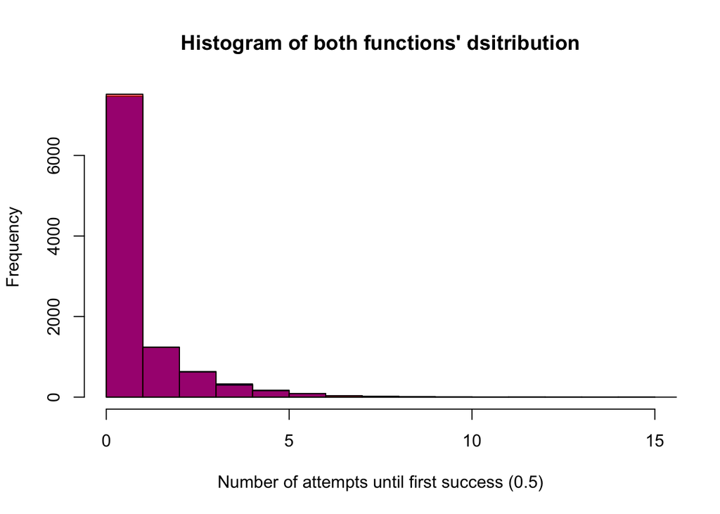

```r
sims <- 10000
cols = 3
p = .5
df3 <- data.frame(matrix(NA,nrow=sims,ncol=cols))
for (i in 1:sims){
  df3[i,1] <- rgeom(1,p)
  df3[i,2] <- myattempts(p)
}
c1 <- rgb(0,0,255,max = 255, alpha = 250, names = "blue")
c2 <- rgb(255,0,0, max = 255, alpha = 150, names = "red")
hga <- hist(df3$X1, plot = FALSE)
hgb <- hist(df3$X2, plot = FALSE)
plot(hga, col=c1, main = "Histogram of both functions' dsitribution", xlab='Number of attempts until first success (0.5)')
plot(hgb, col=c2, add=TRUE)
```

### Comparison

It’s barely visible, but the histograms are stacked on top of each other, which means that the distribution is the same.

**d**. For the fourth p, make side-by-side box plots. (5 points)

```r
sims <- 10000
cols = 3
p = .7
df4 <- data.frame(matrix(NA,nrow=sims,ncol=cols))
for (i in 1:sims){
  df4[i,1] <- rgeom(1,p)
  df4[i,2] <- myattempts(p)
}
library(reshape)
```

```r
library(ggplot2)
df4.1 <- melt(df4)
```

```
## Using  as id variables
```

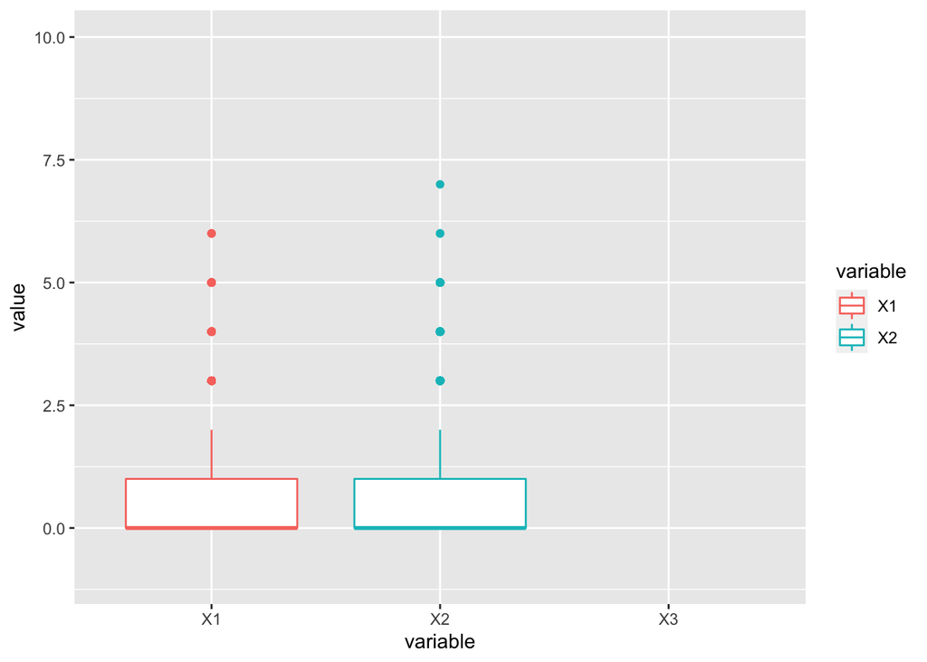

```r
df4.1$value <- df4.1$value
ggplot(df4.1) + geom_boxplot(aes(x=variable, y=value, color=variable)) + ylim(-1, 10)
```

### Comaparison

The box plots again show the same distribution. Even the outliers are of the same magnitude.

**e**. For the fifth p, plot the two empirical distribution functions in the same plot. (5 points)

```r
sims <- 10000
cols = 3
p = .2
df5 <- data.frame(matrix(NA,nrow=sims,ncol=cols))
for (i in 1:sims){
  df5[i,1] <- rgeom(1,p)
  df5[i,2] <- myattempts(p)
}
df5.1 <- melt(df5)
```

```
## Using  as id variables
```

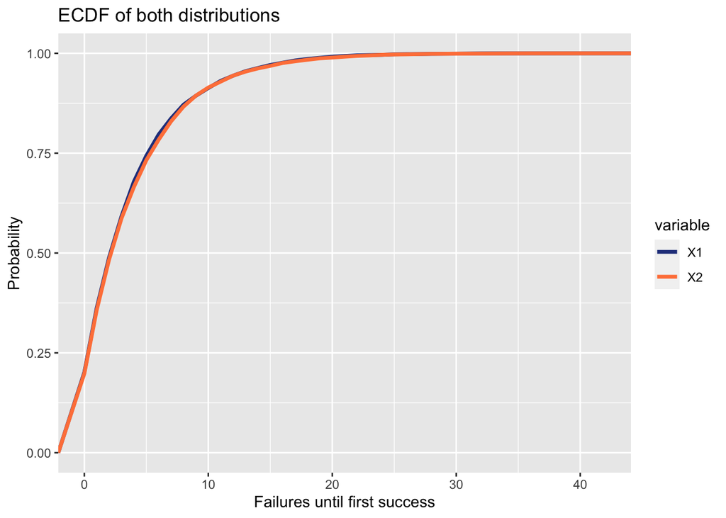

```r
library(ggplot2)
colors <- c( 'royalblue4', 'sienna1')
ggplot(df5.1, aes(x = value, color = variable)) + scale_color_manual(values = colors) + stat_ecdf(lwd = 1.25, geom = "line") +
  ggtitle('ECDF of both distributions') + labs(x='Failures until first success',y='Probability')
```

### Comparison

The ecdfs give the same line. They are barely distinguishable; just like the histograms from earlier.

## Problem 2

Consider the following random experiment: draw a uniformly distributed random number X1 from the interval (0, 1). Next, draw a uniformly distributed random number X2 from the interval (0, 1 + X1), a uniformly distributed random number X3 from the interval (0, 1 + X2) and so on until X20. Use a monte carlo simulation to give an approximate answer to What is the mean value of X20? and use a histogram to identify the distribution of X20. X1 ∼unif(0,1)X2 ∼unif(0,1+X1)X3 ∼unif(0,1+X2). . . X20 ∼unif(0,1+X19) The R command for drawing a uniformly distributed random number from the interval (0, b) is runif(1,min = 0, max = b).

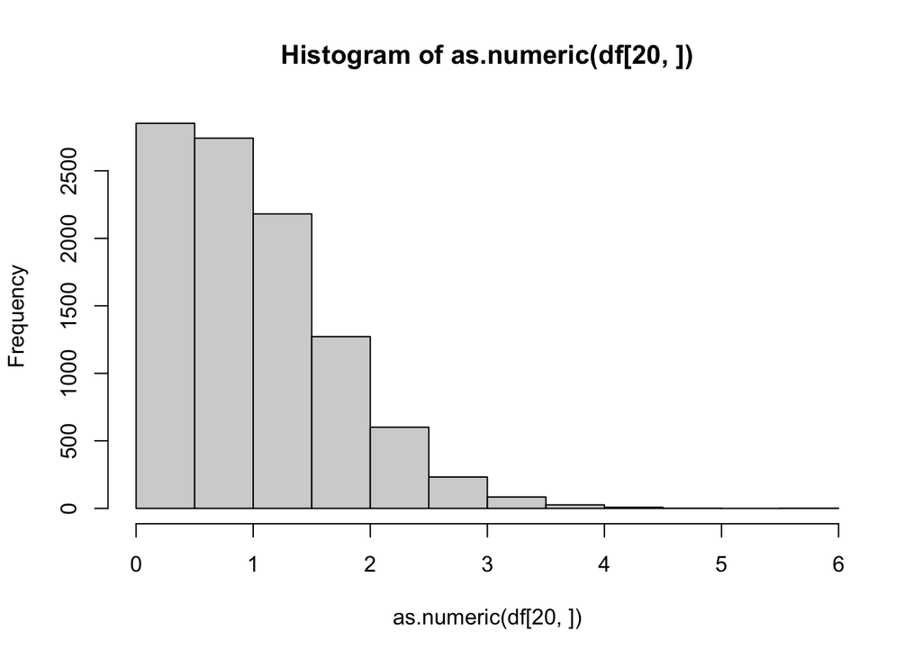

```r
iters = 10000
df <- data.frame(matrix(NA,ncol=iters,nrow=20))
for (z in 1:iters){
  x <- 0
  for (i in 1:20){
    value <- runif(1, min=0, max=1+x)
    x <- value
    df[i,z] <- value
  }
}
hist(as.numeric(df[20,]))
```

```r
mean(as.numeric(df[20,]))
```

```
## [1] 1.000722
```

## Problem 3

Suppose that the daily power consumption of a major city, X, has a Gamma distribution with shape parameter r = 4 and scale parameter ρ = 2. Use R to compute the following quantities:

1. Prob(X ≤ 12) (3 Points)

```r
pgamma(q=12,shape=4,scale=2)
```

```
## [1] 0.8487961
```

2. Prob(X > 5) (3 Points)

```r
pgamma(q=5,shape=4,scale=2,lower.tail = FALSE)
```

```
## [1] 0.7575761
```

3. Prob(|X − 8|) < 1 (4.5 Points)

```r
1 - (pgamma(q=7,shape=4,scale=2,lower.tail = TRUE) + pgamma(q=9,shape=4,scale=2,lower.tail = FALSE))
```

```
## [1] 0.1943367
```

4. z such that Prob(X < z) = .95 (4.5 Points)

```r
qgamma(p=0.95,shape=4,scale=2)
```

```
## [1] 15.50731
```